# Main US - Univariate analysis

Fabio Torreggiani

Created: 30th November 2023; Updated:

Purpose: Running descriptive analysis on all the measured variables, divided by mechanism and, when needed, compared with either the reference population.

# Summary

- **Twitter**. Half of the sample has it and uses it regularly, especially for lurking (74% at least once a week; 60% for active use).
- **Cognitive effort**. Tasks where quite difficult: 73% of sample got 0 correct, another 15% got just one correct and only around 5% got all correct.
- **Politics**. If we look at party affiliation Democrats are over-represented. If we look at political orientation, Left-Right orientation present a quasi-normal distribution, with anchoring on the extremes and at the center, with a lot of people in the center of the scale, but more people on the right than on the left.
- **Institutions**. Problematic percentage of “I prefer not to answer” on trust in Parliament (11%). Relatively low trust, but higher than in italian case. All institutions with mean below middle point of the scale, except for Universities. Social media have the lowest trust (mean 0.41/1). Social media the one with highest SD, but not radically different from others. In general, Press, Parliament and Government have the more similar distributions. Trust in science is pretty high according to both measures. Other considerations in PCA report.
- **Anti-elitism**. Distributions are very different to the Italian case. Similarly to Italy, the distribution of the first item (politicians talk too much), is squeezed to the top of the scale. However, the second item (differences between people and the elite) have high frequencies from the middle to the top of the scale. Surprisingly, the third item (politicians think about the people) is almost a flat distribution. Similarly to the Italian case, the third item is the most (negatively) correlated with trust in institutions. This was partially the case also for the first item, which here is not correlated at all with institutions. Interestingly, the second item is here *positively* (slightly) correlated with trust in institutions.
- **Social Norms - Beliefs**. Clear and strong preference for accuracy. This is especially true for personal normative beliefs, where 60% put accuracy as their first priority. This is an indication that participants understood the questions and that there is a fraction of people recognizing that they value interest when they should value accuracy.
- **Social Norms - Expectations**. People are quite good at guessing the “unclear/mixed” situation regarding the norm. The mode answer is “more or less half of the sample”, followed by “around three quarter”. This result is true for both empirical and normative expectations and it is the same as in the Italian convenience sample. Also, there is a link between beliefs and expectations, but not a very strong one: the incidence of people choosing “accuracy” is higher in those who put “almost everyone” and “three quarters”, especially for the normative expectations.
- **Media Consumption**. The most consumed media are internet, phones and tv news, which are consumed more ore less by everyone and on a very frequent base. Other media are more “niche”, in the sense that they have both people using them a lot and others using them never or very rarely: social media and emails. Friends are consumed by more or less everyone, but with varying frequency. Traditional media, like newspapers and radionews appears to be much less used than in the Italian sample, although they still have around 40% of the sample using them at least once a week. Differently from the Italian sample, in all media there is around 20% of the sample who *never* uses it. This highlights a more fragmented media world with some people completely avoding certain media.
- **Perceived Accuracy**. Sort of bi-modal, but not coinciding with the two extremes: “extremely accurate” is the least chosen category. In general, people were both skeptical (generally low scores, even for reliable news), and good at discerning news (still, there is a gap between fake and reliable news). Interestingly, the most chosen category is “I don’t know”, highlighting a more cautious approach to news evaluation.
- **Perceived Accuracy - Events**. Differently to what noted in other studies (preparatory studies and the convenience sample), people were good at discerning news, independently of the event analysed. For 15 out of 20 events the reliable news is significantly perceived as more accurate than the fake news. Then, there are five events for which the scores are not statistically distinguishable between the true and fake news. This result could also be simply due to the higher numerosity of the sample.
- **Perceived Accuracy - Round and Treatment**. No effect of round: people are not better (nor worse) as the survey proceed. No effect of treatment: truth discernment is not better or worse after the treatment, in none of the groups.
- **Robustness Checks - Individual Perceived Accuracy**. In general, the distribution is very close to a normal one. Divided by veracity, the curve for fake news is squeezed toward the bottom of the scale and seems “cut”: a lot of people choose the bottom of the scale for fake news. Individual truth discernment present a normal distribution with and a relatively strong right skewness: there are a lot of people with positive truth discernment and there are some with perfect or almost perfect scores.
- **Robustness Checks - Balance of news**. The balance of news (% of fake news over the ten items) is a normal distribution (randomization worked correctly). There is no effect of balance on truth discernment: people judged items one by one, without inferring the balance of true vs fake news and trying to guess the accuracy based on that.
- **Sharing behavior**. As expected, it is a very rare behaviour and linked with perceived accuracy (correlation of 0.5), although weakly so and much weakly if compared to the italian sample.

# Demographics

## Age

```r
part_df$DEM_AGE %>% summary()
```

```
##    Min. 1st Qu.  Median    Mean 3rd Qu.    Max.    NA's
##    17.0    29.0    41.0    44.4    61.0    99.0       7
```

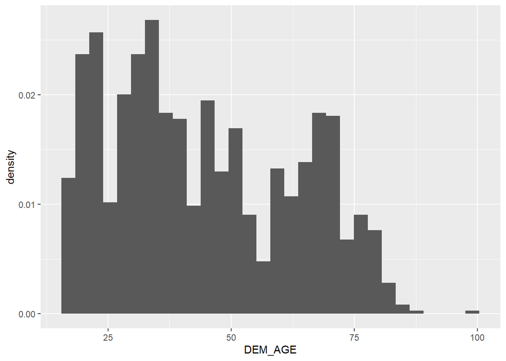

```r
part_df %>% ggplot(aes(x = DEM_AGE)) +
  geom_histogram(aes(y = ..density..)) +
  stat_function(fun = ~dnorm(.x,
                             mean = mean(part_df$DEM_AGE),
                             sd = sd(part_df$DEM_AGE)))
```

```r
part_df$DEM_AGECat %>% table() %>% prop.table()
```

```
## .
##   35-44   25-34   45-54  55plus   18-24
## 0.18254 0.19444 0.14762 0.32222 0.15317
```

## Gender

```r
part_df$DEM_GENDER %>% table() %>% prop.table()
```

```
## .
##                       Man                     Woman Non-binary / third gender
##                 0.4559174                 0.5250199                 0.0079428
##   Prefer to self-identify         Prefer not to say
##                 0.0039714                 0.0071485
```

## Education

```r
part_df$DEM_EDU4Cat %>% table() %>% prop.table()
```

```
## .
## MiddleSchool   HighSchool     Bachelor       Master
##     0.048451     0.330421     0.467832     0.153296
```

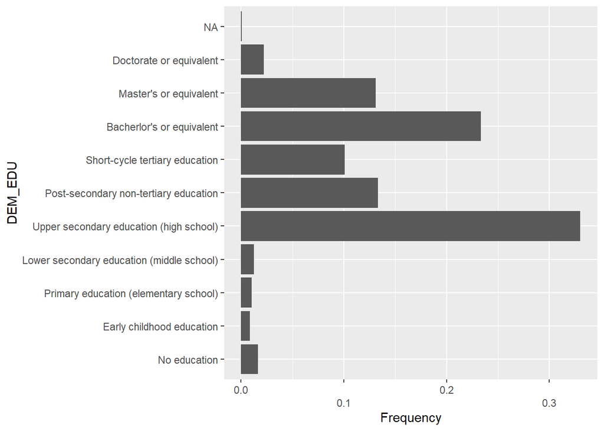

```r
part_df %>% ggplot(aes(x = DEM_EDU)) +
  geom_bar(aes (y = (..count..)/sum(..count..))) +
  guides(x = guide_axis(n.dodge = 2)) +
  labs(y = "Frequency") +
  coord_flip()
```

## Profession

```r
var_n = "DEM_PROF"
part_df[[var_n]] %>% table() %>% prop.table()
```

```
## .
##                                            Manager
##                                           0.269968
##                                       Professional
##                                           0.178914
##               Technician or associate professional
##                                           0.069489
##                            Clerical support worker
##                                           0.086262
##                          Service and sales workers
##                                           0.136581
## Skilled agricultural, forestry and fishery workers
##                                           0.014377
##                        Craft related trade workers
##                                           0.031150
##        Plant and machine operators, and assemblers
##                                           0.021565
##                             Elementary occupations
##                                           0.029553
##                           Armed forces occupations
##                                           0.019169
##                            I have never worked yet
##                                           0.142971
```

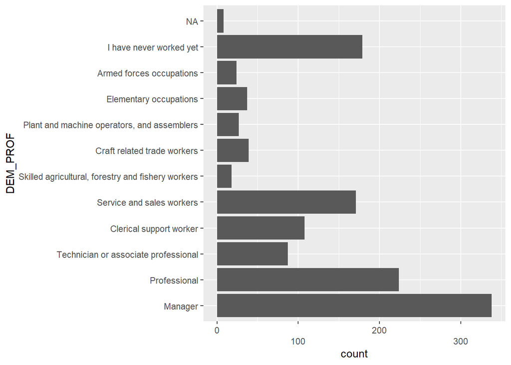

```r
part_df %>% ggplot(aes(x = part_df[[var_n]])) +
  geom_bar() +
  guides(x = guide_axis(n.dodge = 2)) +
  labs(x = var_n) +
  coord_flip()
```

```r
#+
  #geom_text(aes(label = after_stat(count)), stat = "count", vjust = -0.5, colour = "black")
```

# Twitter

## Have

```r
var_n = "TWH"
part_df[[var_n]] %>% table() %>% prop.table()
```

```
## .
##     Yes      No
## 0.49127 0.50873
```

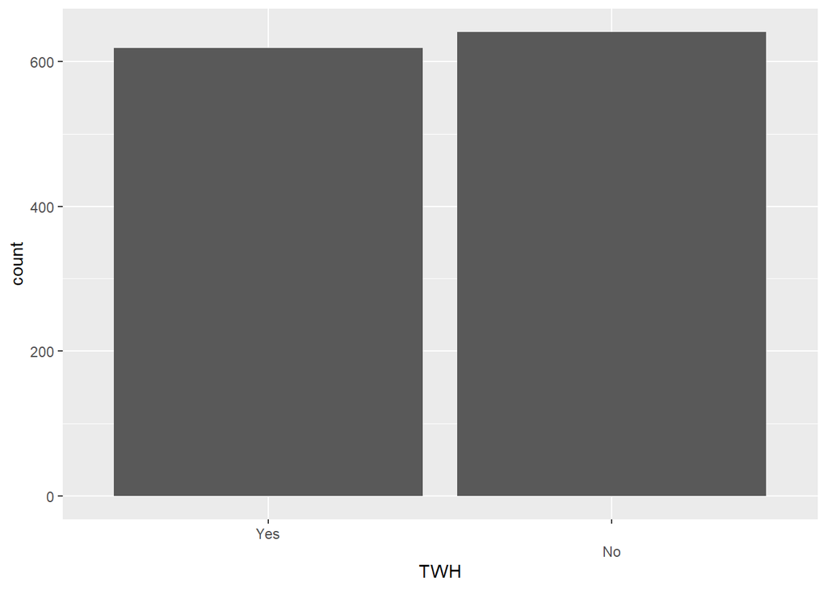

```r
part_df %>% ggplot(aes(x = .data[[var_n]])) +
  geom_bar() +
  guides(x = guide_axis(n.dodge = 2)) +
  labs(x = var_n) #+
```

```r
  #geom_text(aes(label = after_stat(count)), stat = "count", vjust = -0.5, colour = "black")
```

## Lurk

```r
var_n = "TWLURK"
part_df[[var_n]] %>% table() %>% prop.table()
```

```
## .
##                 Never           Once a year Once every few months
##             0.0397924             0.0553633             0.0934256
##          Once a month           Once a week      2-3 times a week
##             0.0709343             0.1003460             0.1591696
##      4-6 times a week         Daily or more     Prefer not to say
##             0.1349481             0.3442907             0.0017301
```

```r
# Cumulative sum
part_df[[var_n]] %>% table() %>% rev() %>% prop.table() %>% cumsum()
```

```
##     Prefer not to say         Daily or more      4-6 times a week
##             0.0017301             0.3460208             0.4809689
##      2-3 times a week           Once a week          Once a month
##             0.6401384             0.7404844             0.8114187
## Once every few months           Once a year                 Never
##             0.9048443             0.9602076             1.0000000
```

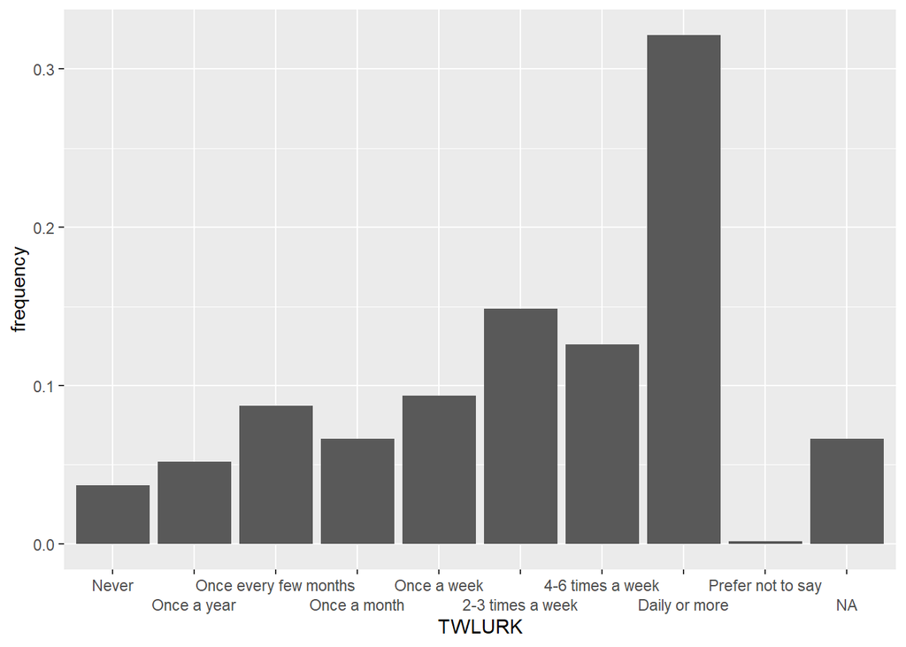

```r
part_df %>% filter(TWH == "Yes") %>%
  ggplot(aes(x = .data[[var_n]])) +
  geom_bar(aes(y = (..count..)/sum(..count..))) +
  guides(x = guide_axis(n.dodge = 2)) +
  labs(x = var_n, y = "frequency")
```

## Interact

```r
var_n = "TWACTIVE"
part_df[[var_n]] %>% table() %>% prop.table()
```

```
## .
##                 Never           Once a year Once every few months
##             0.0953206             0.0710572             0.1403813
##          Once a month           Once a week      2-3 times a week
##             0.0883882             0.1247834             0.1785095
##      4-6 times a week     Prefer not to say
##             0.2928943             0.0086655
```

```r
# Cumulative sum
part_df[[var_n]] %>% table() %>% rev() %>% prop.table() %>% cumsum()
```

```
##     Prefer not to say      4-6 times a week      2-3 times a week
##             0.0086655             0.3015598             0.4800693
##           Once a week          Once a month Once every few months
##             0.6048527             0.6932409             0.8336222
##           Once a year                 Never
##             0.9046794             1.0000000
```

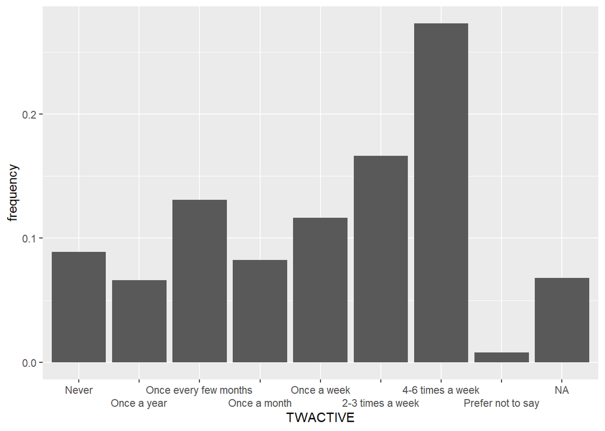

```r
part_df %>% filter(TWH == "Yes") %>%
  ggplot(aes(x = .data[[var_n]])) +
  geom_bar(aes(y = (..count..)/sum(..count..))) +
  guides(x = guide_axis(n.dodge = 2)) +
  labs(x = var_n, y = "frequency")
```

# Cognitive Tasks

```r
part_df$CRT %>% table() %>%
  transform(cumFreq = cumsum(Freq),
            relative = prop.table(Freq),
            cumRel = cumsum(prop.table(Freq)))
```

```
##      . Freq cumFreq relative  cumRel
## 1    0  924     924 0.733333 0.73333
## 2 0.33  201    1125 0.159524 0.89286
## 3 0.67   83    1208 0.065873 0.95873
## 4    1   52    1260 0.041270 1.00000
```

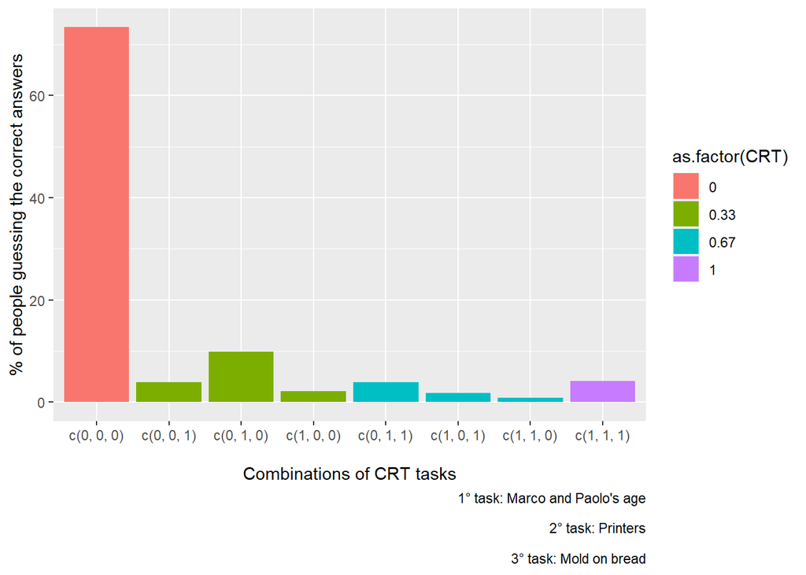

```r
temp_df <- part_df %>% group_by(CRT, COGT1Corr, COGT2Corr, COGT3Corr) %>%
  count() %>% mutate(
  comb = as.character(mapply(c, COGT1Corr, COGT2Corr, COGT3Corr, SIMPLIFY = F)),
  perc = n/nrow(part_df)
)
temp_df %>% ggplot(aes(x = fct_reorder(as.factor(comb), CRT), y = perc*100, fill = as.factor(CRT))) +
  geom_col() +
  labs(x = "\nCombinations of CRT tasks",
       y = "% of people guessing the correct answers",
       caption = "1° task: Marco and Paolo's age\n
       2° task: Printers\n
       3° task: Mold on bread")
```

```r
  #geom_text(aes(n), label = n, vjust = -0.5, colour = "black")
```

# Politics & Ideologies

## Party affiliation

```r
var_n = "POL_party"
part_df[[var_n]] %>% table() %>% prop.table()
```

```
## .
##             Strong Democrat                    Democrat
##                    0.182035                    0.193164
##   Independent Lean Democrat                 Independent
##                    0.060413                    0.145469
## Independent Lean Republican                  Republican
##                    0.065183                    0.131955
##           Strong Republican      No party appeals to me
##                    0.094595                    0.097774
##      I prefer not to answer
##                    0.029412
```

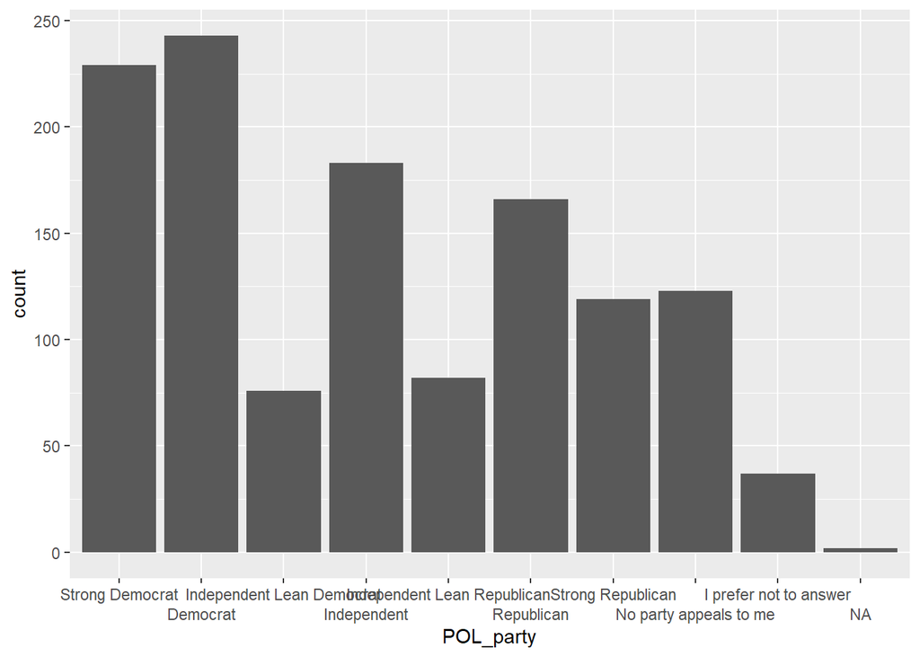

```r
part_df %>% ggplot(aes(x = .data[[var_n]])) +
  geom_bar() +
  guides(x = guide_axis(n.dodge = 2)) +
  labs(x = var_n)
```

### Party Affiliation - Without Abstention

```r
var_n = "POL_party"
part_df[[var_n]][part_df[[var_n]] != "No party appeals to me" & part_df[[var_n]] != "I prefer not to answer"] %>% table() %>% prop.table()
```

```
## .
##             Strong Democrat                    Democrat
##                    0.208561                    0.221311
##   Independent Lean Democrat                 Independent
##                    0.069217                    0.166667
## Independent Lean Republican                  Republican
##                    0.074681                    0.151184
##           Strong Republican      No party appeals to me
##                    0.108379                    0.000000
##      I prefer not to answer
##                    0.000000
```

## PolOr

```r
var_n = "PolOr"
part_df[[var_n]] %>% table() %>% prop.table()
```

```
## .
##                   Left                      1                      2
##               0.085851               0.031002               0.042925
##                      3                      4                      5
##               0.057234               0.049285               0.238474
##                      6                      7                      8
##               0.053259               0.060413               0.078696
##                      9                  Right I prefer not to answer
##               0.043720               0.163752               0.095390
```

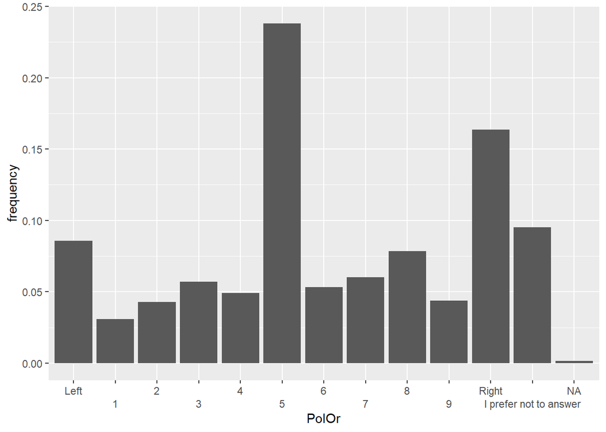

```r
part_df %>%
  ggplot(aes(x = .data[[var_n]])) +
  geom_bar(aes(y = (..count..)/sum(..count..))) +
  guides(x = guide_axis(n.dodge = 2)) +
  labs(x = var_n, y = "frequency")
```

### PolOrNum

```r
var_n = "POL_OrNum"
part_df[[var_n]] %>% summary()
```

```
##    Min. 1st Qu.  Median    Mean 3rd Qu.    Max.    NA's
##    0.00    4.00    5.00    5.62    8.00   10.00     122
```

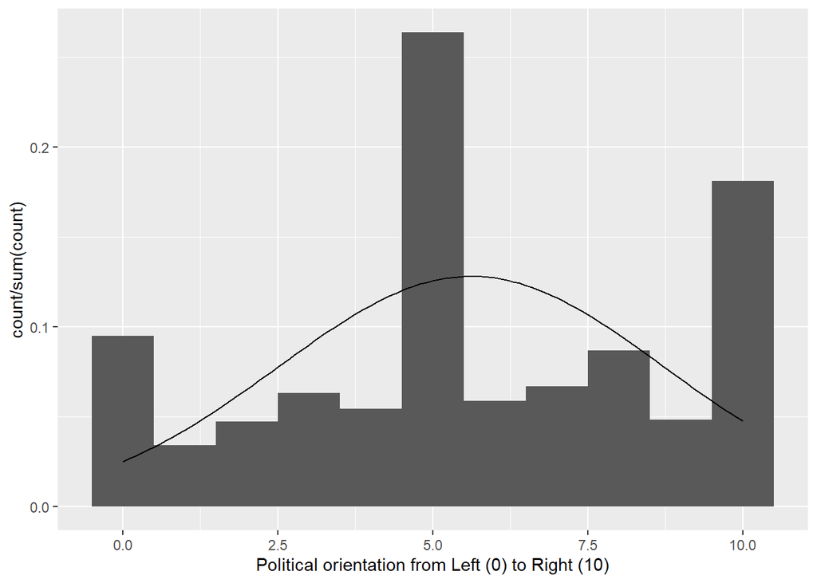

```r
part_df %>% ggplot(aes(x = part_df[[var_n]])) +
  geom_histogram(aes(y = after_stat(count/sum(count))), binwidth = 1) +
  stat_function(fun = ~dnorm(.x,
                             mean = mean(part_df[[var_n]], na.rm = T),
                             sd = sd(part_df[[var_n]], na.rm = T))) +
  labs(x = "Political orientation from Left (0) to Right (10)")
```

```r
part_df[[var_n]] %>% summary()
```

```
##    Min. 1st Qu.  Median    Mean 3rd Qu.    Max.    NA's
##    0.00    4.00    5.00    5.62    8.00   10.00     122
```

```r
sprintf("Mean: %.2f", mean(part_df[[var_n]], na.rm = T))
```

```
## [1] "Mean: 5.62"
```

```r
sprintf("Sd: %.2f", sd(part_df[[var_n]], na.rm = T))
```

```
## [1] "Sd: 3.11"
```

## Ideologies

### Redistribution

```r
myBarPlot <- function(var_n){
  ggplot(aes(x = .data[[var_n]]), data = part_df) +
  geom_bar(aes(y = (..count..)/sum(..count..))) +
  guides(x = guide_axis(n.dodge = 2)) +
  labs(x = var_n, y = "frequency") +
  scale_x_discrete(label = function(x) stringr::str_trunc(x, 30)) +
  coord_flip()
}

mySummary <- function(var_n){
  a <- sprintf("Summary of: %s", var_n)
  b <- part_df[[paste0(var_n, "Num")]] %>% summary()
  c <- sprintf("Mean: %.3f", mean(part_df[[paste0(var_n, "Num")]], na.rm = T))
  d <- sprintf("Sd: %.3f", sd(part_df[[paste0(var_n, "Num")]], na.rm = T))
  cat(a, "\n")
  print(b)
  cat(c, d)
}
```

```r
var_n = "POL3"
part_df[[var_n]] %>% table() %>% prop.table()
```

```
## .
##                        Incomes should be made more equal
##                                                 0.160828
##                                                        1
##                                                 0.034236
##                                                        2
##                                                 0.038217
##                                                        3
##                                                 0.046178
##                                                        4
##                                                 0.030255
##                                                        5
##                                                 0.152070
##                                                        6
##                                                 0.062102
##                                                        7
##                                                 0.074045
##                                                        8
##                                                 0.070064
##                                                        9
##                                                 0.062898
## There should be greater incentives for individual effort
##                                                 0.222930
##                                   I prefer not to answer
##                                                 0.046178
```

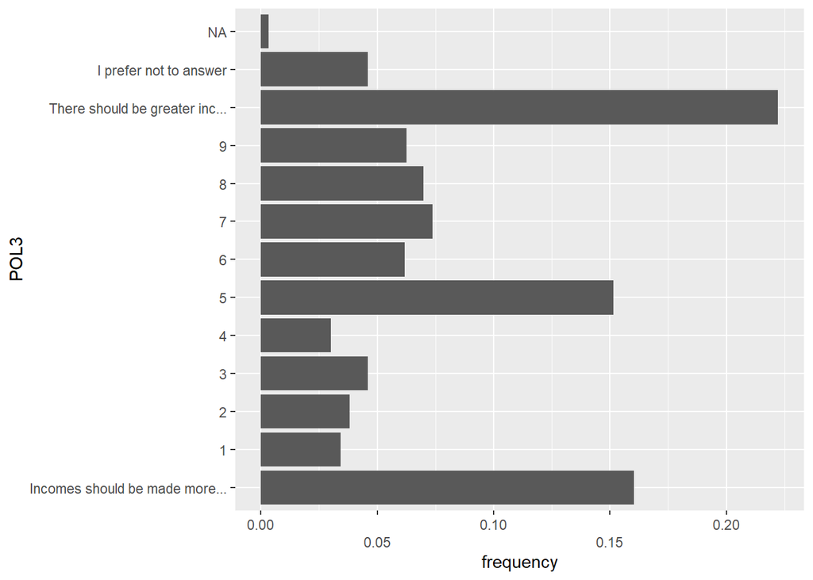

```r
myBarPlot(var_n)
```

```r
mySummary(var_n)
```

```
## Summary of: POL3
##    Min. 1st Qu.  Median    Mean 3rd Qu.    Max.    NA's
##   0.000   0.300   0.600   0.564   0.900   1.000      62
## Mean: 0.564 Sd: 0.359
```

### Well-being responsability

```r
var_n = "POL4"
part_df[[var_n]] %>% table() %>% prop.table()
```

```
## .
## Government should take more responsibility to ensure that everyone is provided for
##                                                                           0.167994
##                                                                                  1
##                                                                           0.030255
##                                                                                  2
##                                                                           0.042197
##                                                                                  3
##                                                                           0.058121
##                                                                                  4
##                                                                           0.063694
##                                                                                  5
##                                                                           0.130573
##                                                                                  6
##                                                                           0.054936
##                                                                                  7
##                                                                           0.084395
##                                                                                  8
##                                                                           0.082803
##                                                                                  9
##                                                                           0.058121
##                   People should take more responsibility to provide for themselves
##                                                                           0.191879
##                                                             I prefer not to answer
##                                                                           0.035032
```

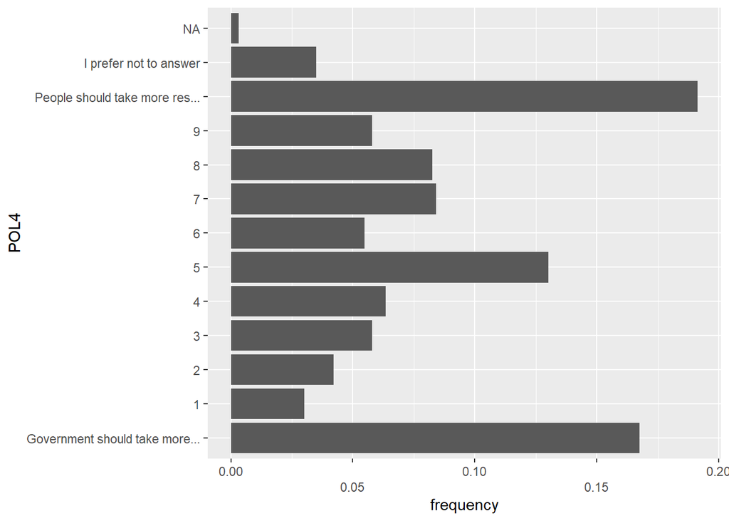

```r
myBarPlot(var_n)
```

```r
mySummary(var_n)
```

```
## Summary of: POL4
##    Min. 1st Qu.  Median    Mean 3rd Qu.    Max.    NA's
##   0.000   0.300   0.500   0.541   0.900   1.000      48
## Mean: 0.541 Sd: 0.354
```

### Moral Rules

```r
var_n = "POL5"
part_df[[var_n]] %>% table() %>% prop.table()
```

```
## .
##       Completely agree                      1                      2
##               0.217184               0.038186               0.054893
##                      3                      4                      5
##               0.073986               0.075577               0.155131
##                      6                      7                      8
##               0.061257               0.062053               0.071599
##                      9    Completely disagree I prefer not to answer
##               0.046937               0.098648               0.044551
```

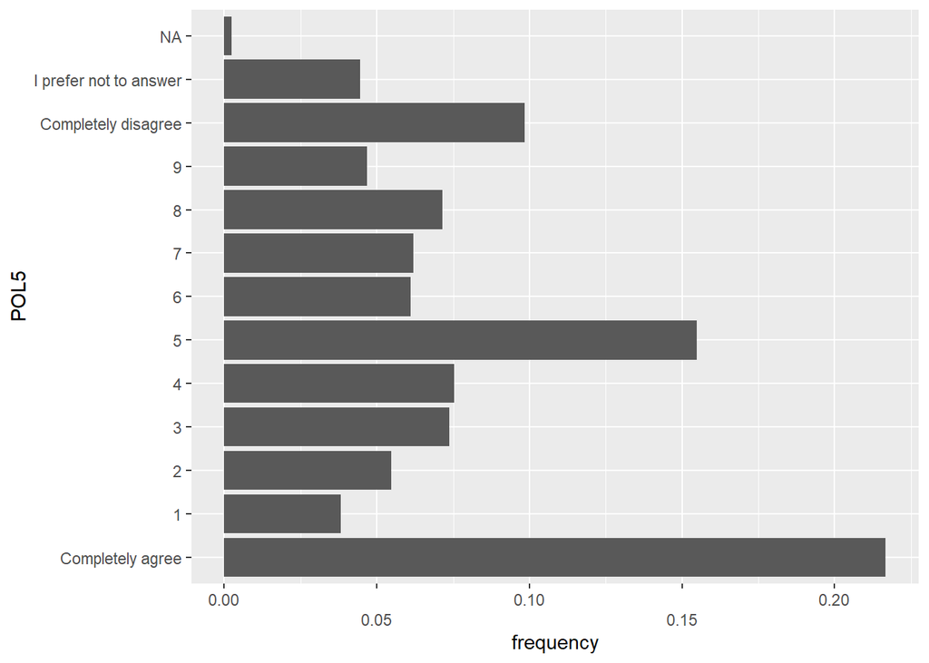

```r
myBarPlot(var_n)
```

```r
mySummary(var_n)
```

```
## Summary of: POL5
##    Min. 1st Qu.  Median    Mean 3rd Qu.    Max.    NA's
##   0.000   0.100   0.500   0.443   0.700   1.000      59
## Mean: 0.443 Sd: 0.336
```

### Importance of Democracy

```r
var_n = "POL6"
part_df[[var_n]] %>% table() %>% prop.table()
```

```
## .
##   Not at all important                      1                      2
##               0.058964               0.011155               0.018327
##                      3                      4                      5
##               0.019920               0.039044               0.101195
##                      6                      7                      8
##               0.042231               0.069323               0.090837
##                      9   Absolutely important I prefer not to answer
##               0.078088               0.412749               0.058167
```

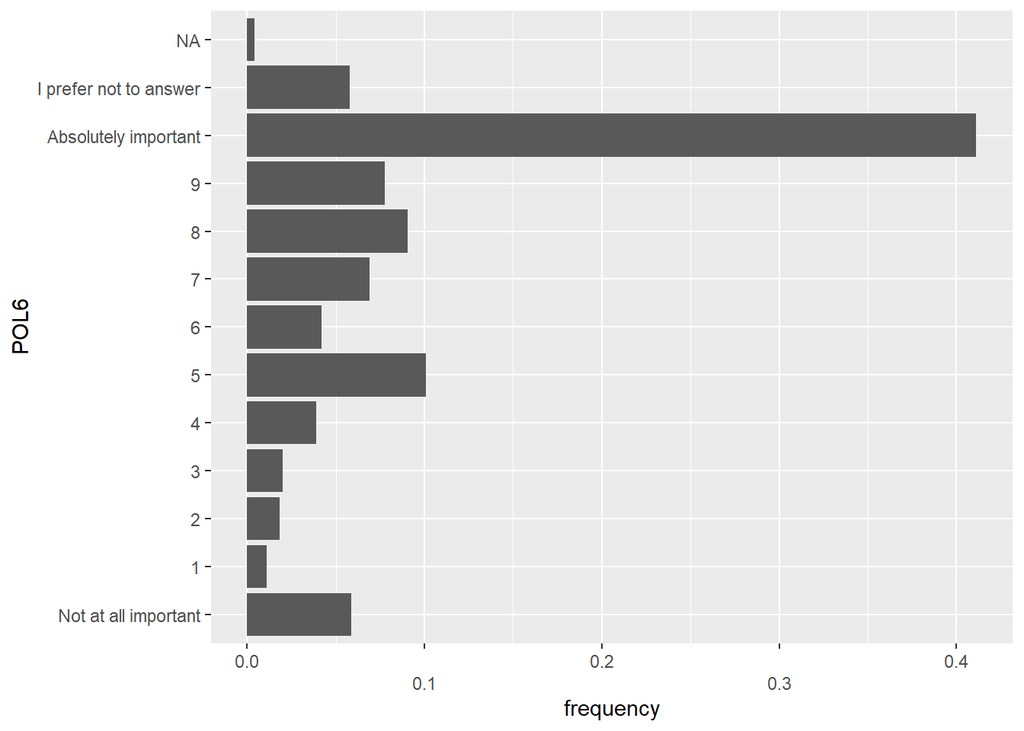

```r
myBarPlot(var_n)
```

```r
mySummary(var_n)
```

```
## Summary of: POL6
##    Min. 1st Qu.  Median    Mean 3rd Qu.    Max.    NA's
##    0.00    0.50    0.90    0.75    1.00    1.00      78
## Mean: 0.750 Sd: 0.305
```

## Correlation Matrix and possible index

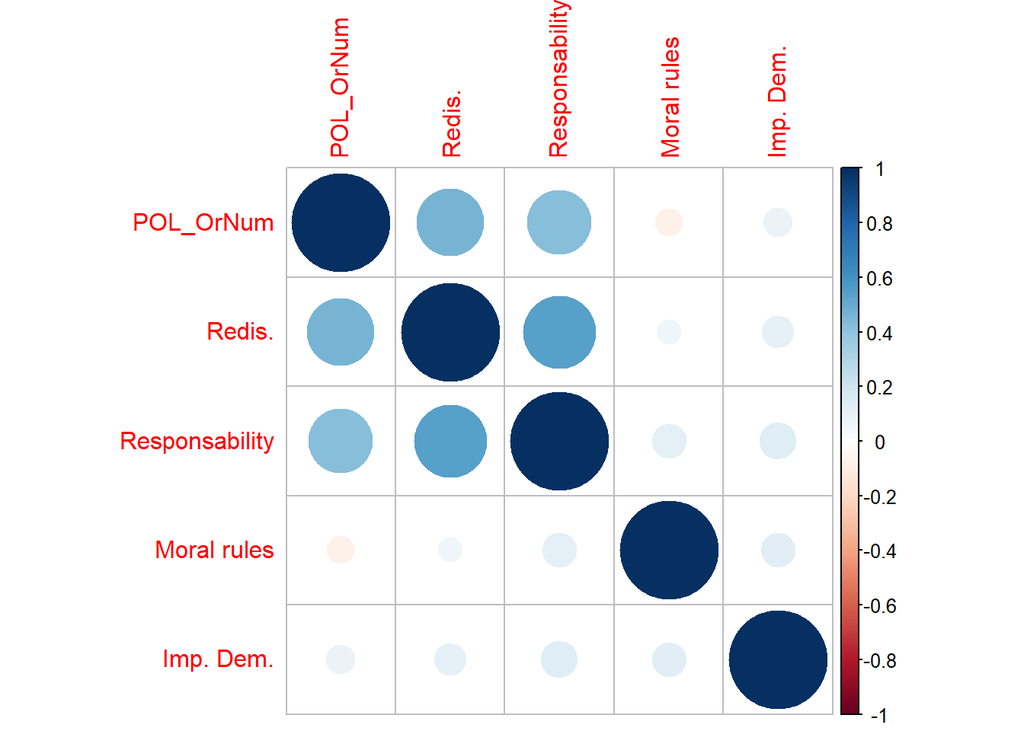

```r
temp_df <- part_df %>% select(POL_OrNum:POL6Num) %>% cor(use = "complete.obs")
colnames(temp_df) <- c("POL_OrNum", "Redis.", "Responsability", "Moral rules", "Imp. Dem.")
rownames(temp_df) <- c("POL_OrNum", "Redis.", "Responsability", "Moral rules", "Imp. Dem.")
temp_df %>% corrplot::corrplot()
```

# Institutional Trust

## Institutions

### “I prefer not to answer” for each institution

```r
var_n = "INST.Press"
var_i = match(var_n, names(part_df))
for (i in var_i:(var_i + 4)) {
  temp_df <- part_df[,i] %>% table() %>% prop.table()
  cat(sprintf("%s: %s%% \n", names(part_df)[i], round(temp_df[11], 4)*100))
}
```

```
## INST.Press: 2.95%
## INST.Parliament: 11%
## INST.Government: 3.03%
## INST.SocialMedia: 1.99%
## INST.Universities: 3.27%
```

Problematic % of I prefer not to answer to the Parliament question (11%).

### Trust in institutions

```r
my_plot <- function(data, x){
  p <- ggplot(data,
         aes(x = .data[[x]])) +
    geom_bar() +
    theme(legend.position = "none") +
    ylim(0,300)
  #return(p)
}

my_plot <- function(data, x){
  p <- ggplot(data,
         aes(x = .data[[x]])) +
    geom_bar(aes(y = after_stat(count/sum(count)))) +
    theme(legend.position = "none") +
    ylim(0,0.25) +
    labs(y = "Frequency")
  #return(p)
}

var_n = "IT_Press"
var_i = match(var_n, names(part_df))

inst <- names(part_df)[var_i:(var_i + 4)]

l <- lapply(inst, my_plot, data = part_df)
```

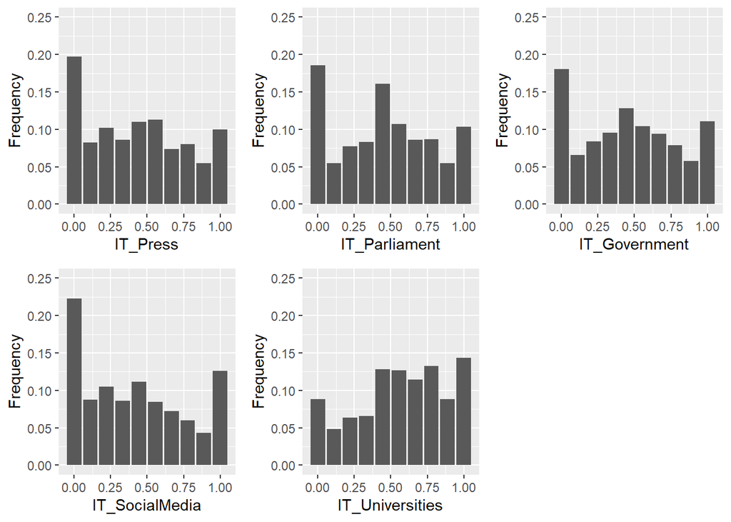

```r
ggpubr::ggarrange(l[[1]], l[[2]], l[[3]], l[[4]],
                  l[[5]],
                  ncol=3, nrow=2, common.legend = TRUE, legend="bottom") %>% print()
```

### Index

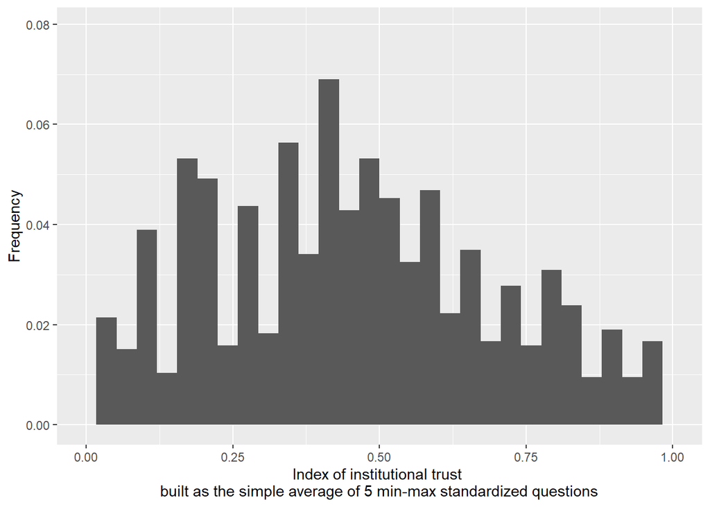

```r
var_n = "inst_tr"
part_df %>% ggplot(aes(x = inst_tr)) +
  geom_histogram(aes(y = after_stat(count/sum(count)))) +
  xlim(0,1) +
  labs(x = "Index of institutional trust \nbuilt as the simple average of 5 min-max standardized questions",
       y = "Frequency")
```

```r
part_df %>% select(IT_Press:IT_Universities, inst_tr) %>% summary()
```

```
##  IT_Press.INST_1 IT_Parliament.INST_2 IT_Government.INST_3
##  Min.   :0.000   Min.   :0.000        Min.   :0.000
##  1st Qu.:0.111   1st Qu.:0.222        1st Qu.:0.222
##  Median :0.444   Median :0.444        Median :0.444
##  Mean   :0.433   Mean   :0.459        Mean   :0.459
##  3rd Qu.:0.667   3rd Qu.:0.667        3rd Qu.:0.667
##  Max.   :1.000   Max.   :1.000        Max.   :1.000
##  NA's   :42      NA's   :143          NA's   :45
##  IT_SocialMedia.INST_4 IT_Universities.INST_5    inst_tr
##  Min.   :0.0000        Min.   :0.000          Min.   :0.000
##  1st Qu.:0.1111        1st Qu.:0.333          1st Qu.:0.222
##  Median :0.3333        Median :0.556          Median :0.422
##  Mean   :0.4180        Mean   :0.570          Mean   :0.445
##  3rd Qu.:0.6667        3rd Qu.:0.778          3rd Qu.:0.644
##  Max.   :1.0000        Max.   :1.000          Max.   :1.000
##  NA's   :31            NA's   :46
```

```r
cat("\n\nStandard Deviations: \n")
```

```
##
##
## Standard Deviations:
```

```r
part_df %>% select(IT_Press:IT_Universities, inst_tr) %>% lapply(sd, na.rm = T)
```

```
## $IT_Press
## [1] 0.33147
##
## $IT_Parliament
## [1] 0.3247
##
## $IT_Government
## [1] 0.32938
##
## $IT_SocialMedia
## [1] 0.3438
##
## $IT_Universities
## [1] 0.30761
##
## $inst_tr
## [1] 0.28279
```

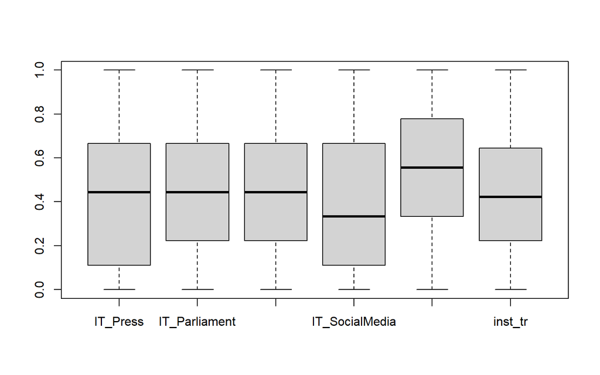

```r
part_df %>% select(IT_Press:IT_Universities, inst_tr) %>% boxplot()
```

## Science

### SCI1 - Life better off

```r
var_n = "SCI1"
part_df[[var_n]] %>% table() %>% prop.table()
```

```
## .
##          Strongly disagree                   Disagree
##                   0.051710                   0.027844
##          Somewhat disagree Neither agree nor disagree
##                   0.078759                   0.151154
##             Somewhat agree                      Agree
##                   0.229912                   0.235481
##             Strongly agree     I prefer not to answer
##                   0.211615                   0.013524
```

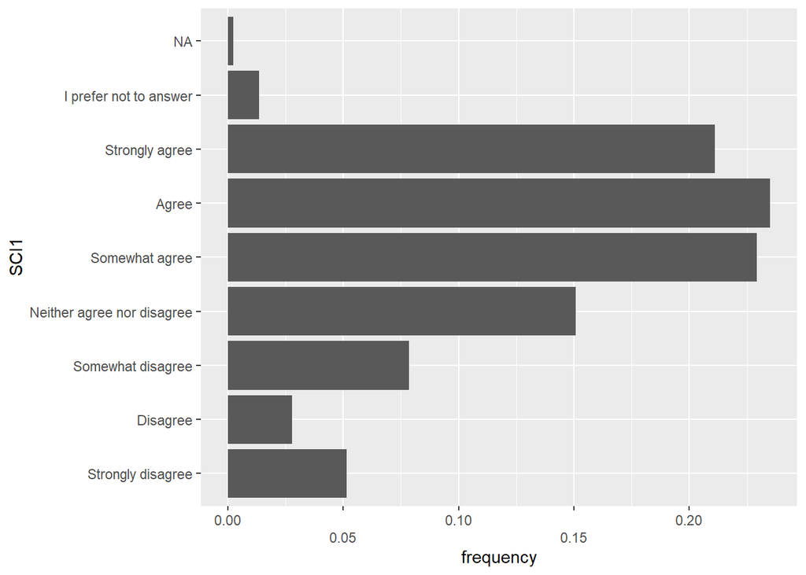

```r
myBarPlot(var_n)
```

```r
mySummary(var_n)
```

```
## Summary of: SCI1
##    Min. 1st Qu.  Median    Mean 3rd Qu.    Max.    NA's
##    0.00    3.00    4.00    4.06    5.00    6.00      20
## Mean: 4.060 Sd: 1.631
```

### SCI2 - World better off

```r
var_n = "SCI2"
part_df[[var_n]] %>% table() %>% prop.table()
```

```
## .
##        A lot worse off                      2                      3
##               0.048528               0.017502               0.027049
##                      4                      5                      6
##               0.052506               0.134447               0.111376
##                      7                      8                      9
##               0.122514               0.153540               0.082737
##       A lot better off I prefer not to answer
##               0.221957               0.027844
```

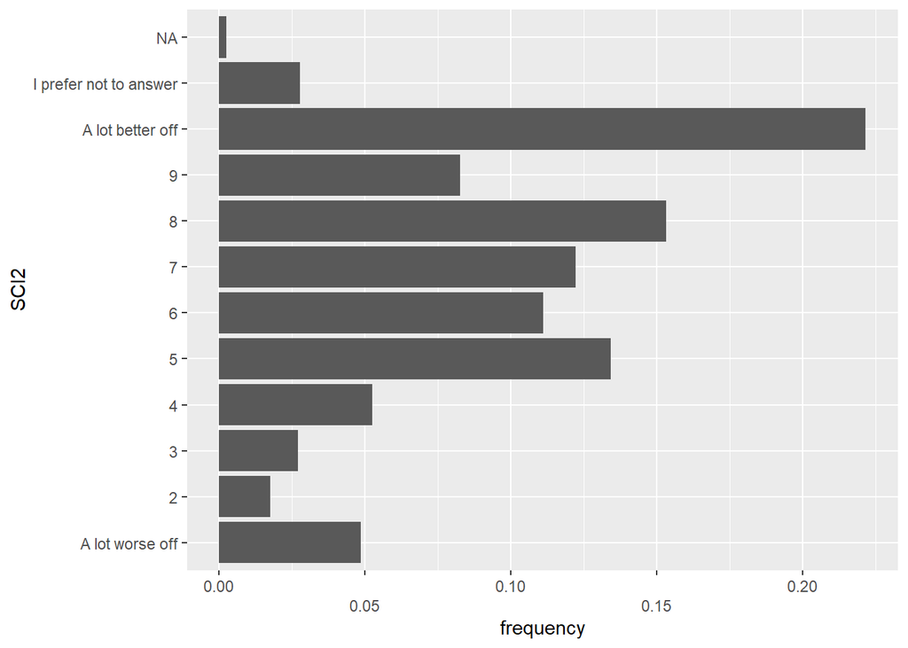

```r
myBarPlot(var_n)
```

```r
mySummary(var_n)
```

```
## Summary of: SCI2
##    Min. 1st Qu.  Median    Mean 3rd Qu.    Max.    NA's
##    0.00    4.00    6.00    5.96    8.00    9.00      38
## Mean: 5.959 Sd: 2.530
```

## Correlation matrix

```r
temp_df <- part_df %>% select(IT_Press:inst_tr, ANTIEL1Num:ANTIELIndex) %>% cor(use = "complete.obs")
temp_df
```

```
##                  IT_Press IT_Parliament IT_Government IT_SocialMedia
## IT_Press         1.000000      0.708701      0.774876       0.636567
## IT_Parliament    0.708701      1.000000      0.769006       0.619180
## IT_Government    0.774876      0.769006      1.000000       0.633390
## IT_SocialMedia   0.636567      0.619180      0.633390       1.000000
## IT_Universities  0.710455      0.666763      0.677223       0.536059
## inst_tr          0.891854      0.874371      0.897488       0.803315
## ANTIEL1Num      -0.026429     -0.022762     -0.048408      -0.073127
## ANTIEL2Num       0.200637      0.180822      0.173445       0.184593
## ANTIEL3Num      -0.559893     -0.551109     -0.613327      -0.570500
## ANTIELIndex     -0.276588     -0.279186     -0.336242      -0.314632
##                 IT_Universities   inst_tr ANTIEL1Num ANTIEL2Num ANTIEL3Num
## IT_Press               0.710455  0.891854  -0.026429    0.20064   -0.55989
## IT_Parliament          0.666763  0.874371  -0.022762    0.18082   -0.55111
## IT_Government          0.677223  0.897488  -0.048408    0.17344   -0.61333
## IT_SocialMedia         0.536059  0.803315  -0.073127    0.18459   -0.57050
## IT_Universities        1.000000  0.829632   0.050921    0.22860   -0.44303
## inst_tr                0.829632  1.000000  -0.029635    0.22476   -0.63926
## ANTIEL1Num             0.050921 -0.029635   1.000000    0.37827    0.07162
## ANTIEL2Num             0.228597  0.224765   0.378265    1.00000   -0.24804
## ANTIEL3Num            -0.443028 -0.639259   0.071620   -0.24804    1.00000
## ANTIELIndex           -0.147897 -0.317738   0.730675    0.53499    0.56243
##                 ANTIELIndex
## IT_Press           -0.27659
## IT_Parliament      -0.27919
## IT_Government      -0.33624
## IT_SocialMedia     -0.31463
## IT_Universities    -0.14790
## inst_tr            -0.31774
## ANTIEL1Num          0.73068
## ANTIEL2Num          0.53499
## ANTIEL3Num          0.56243
## ANTIELIndex         1.00000
```

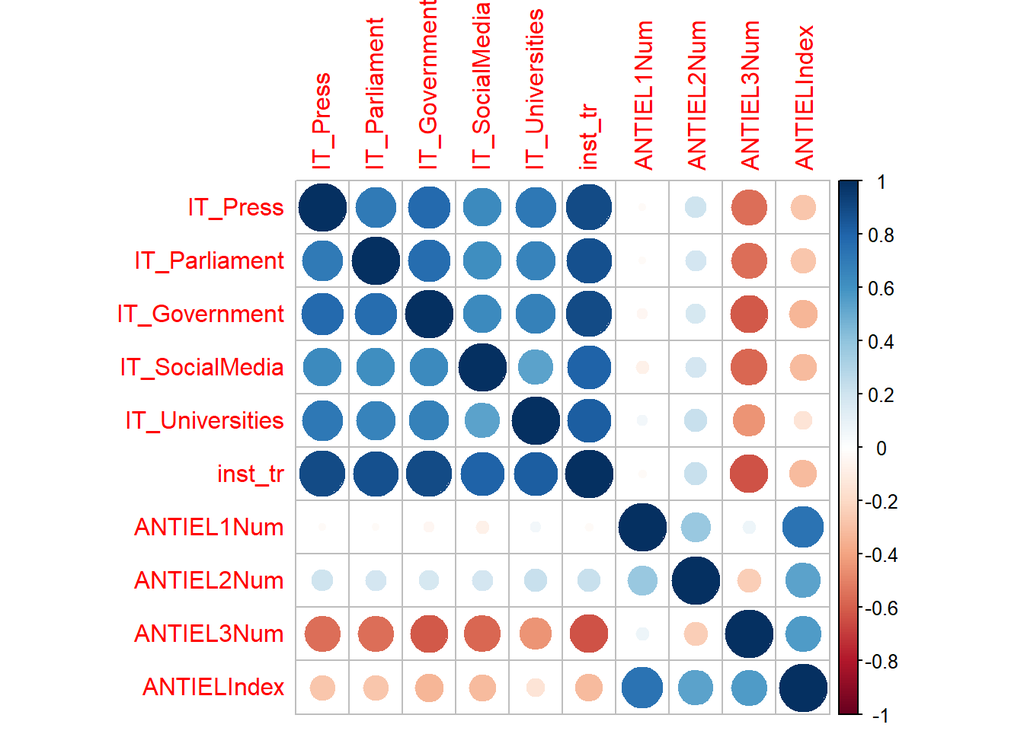

```r
temp_df %>% corrplot::corrplot()
```

## Anti-Elitism

### “I prefer not to answe” per question

```r
var_n = "ANTIEL_1"
var_i = match(var_n, names(part_df))
for (i in var_i:(var_i + 2)) {
  temp_df <- part_df[,i] %>% table() %>% prop.table()
  cat(sprintf("%s: %s%%\n", names(part_df)[i], round(temp_df[8], 5)*100))
}
```

```
## ANTIEL_1: 3.267%
## ANTIEL_2: 5.498%
## ANTIEL_3: 2.951%
```

### Visualization

1- Talk too much

2- Difference between people vs elite

3- Think about people

```r
lbls <- list("ANTIEL1Num" = "Politicians talk too much...",
          "ANTIEL2Num" ="The difference between the people...",
          "ANTIEL3Num" ="Politicians care about...(reversed)",
          "ANTIELIndex" ="Anti-elitism Index")

my_plot <- function(data, x){
  p <- ggplot(data,
         aes(x = .data[[x]])) +
    geom_histogram(aes(y = after_stat(count/sum(count)))) +
    theme(legend.position = "none") +
    ylim(0,0.5) +
    #xlim(0,1.2) +
    labs(x = lbls[[x]],
         y = "Frequency")
  #return(p)
}

var_n = "ANTIEL1Num"
var_i = match(var_n, names(part_df))

vars <- names(part_df)[var_i:(var_i + 4)]

l <- lapply(vars, my_plot, data = part_df)
```

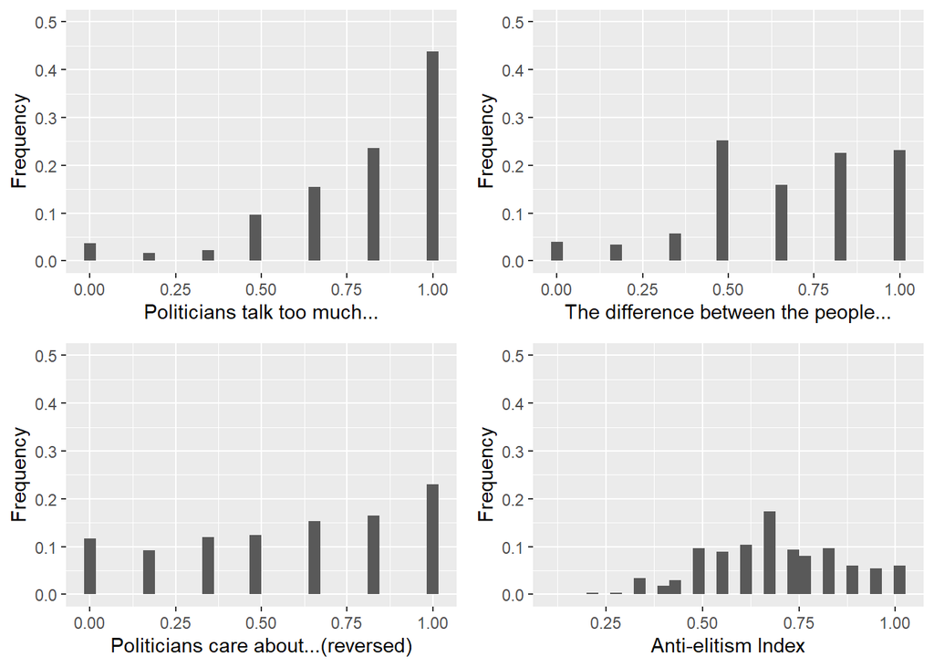

```r
ggpubr::ggarrange(l[[1]], l[[2]], l[[3]], l[[4]],
                  ncol=2, nrow=2, common.legend = TRUE, legend="bottom") %>% print()
```

## Numerical Summary

```r
part_df %>% select(ANTIEL1Num:ANTIELIndex) %>% summary()
```

```
##    ANTIEL1Num      ANTIEL2Num      ANTIEL3Num     ANTIELIndex
##  Min.   :0.000   Min.   :0.000   Min.   :0.000   Min.   :0.111
##  1st Qu.:0.667   1st Qu.:0.500   1st Qu.:0.333   1st Qu.:0.556
##  Median :0.833   Median :0.667   Median :0.667   Median :0.667
##  Mean   :0.795   Mean   :0.676   Mean   :0.586   Mean   :0.686
##  3rd Qu.:1.000   3rd Qu.:0.833   3rd Qu.:0.833   3rd Qu.:0.833
##  Max.   :1.000   Max.   :1.000   Max.   :1.000   Max.   :1.000
##  NA's   :46      NA's   :74      NA's   :43      NA's   :99
```

```r
cat("\n\nStandard Deviations: \n")
```

```
##
##
## Standard Deviations:
```

```r
part_df %>% select(ANTIEL1Num:ANTIELIndex) %>% lapply(sd, na.rm = T)
```

```
## $ANTIEL1Num
## [1] 0.25437
##
## $ANTIEL2Num
## [1] 0.26819
##
## $ANTIEL3Num
## [1] 0.33985
##
## $ANTIELIndex
## [1] 0.17396
```

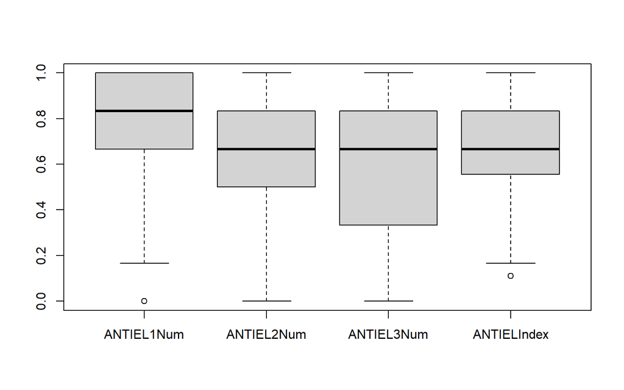

```r
part_df %>% select(ANTIEL1Num:ANTIELIndex) %>% boxplot()
```

# Social Norms

## 0 - Missing Cases

```r
sum(is.na(part_df$SOCNORM1_1))
```

```
## [1] 46
```

```r
sum(is.na(part_df$SOCNORM2))
```

```
## [1] 2
```

```r
sum(is.na(part_df$SOCNORM3_1))
```

```
## [1] 46
```

```r
sum(is.na(part_df$SOCNORM4))
```

```
## [1] 1
```

## 1 - Factual Beliefs

### First Priority

```r
table(part_df$SOCNORM1_1) %>% prop.table() %>% sort(decreasing = T)
```

```
##
##      Accurate   Interesting         Funny All. Politics    Surprising
##      0.556837      0.177100      0.105437      0.085667      0.074959
```

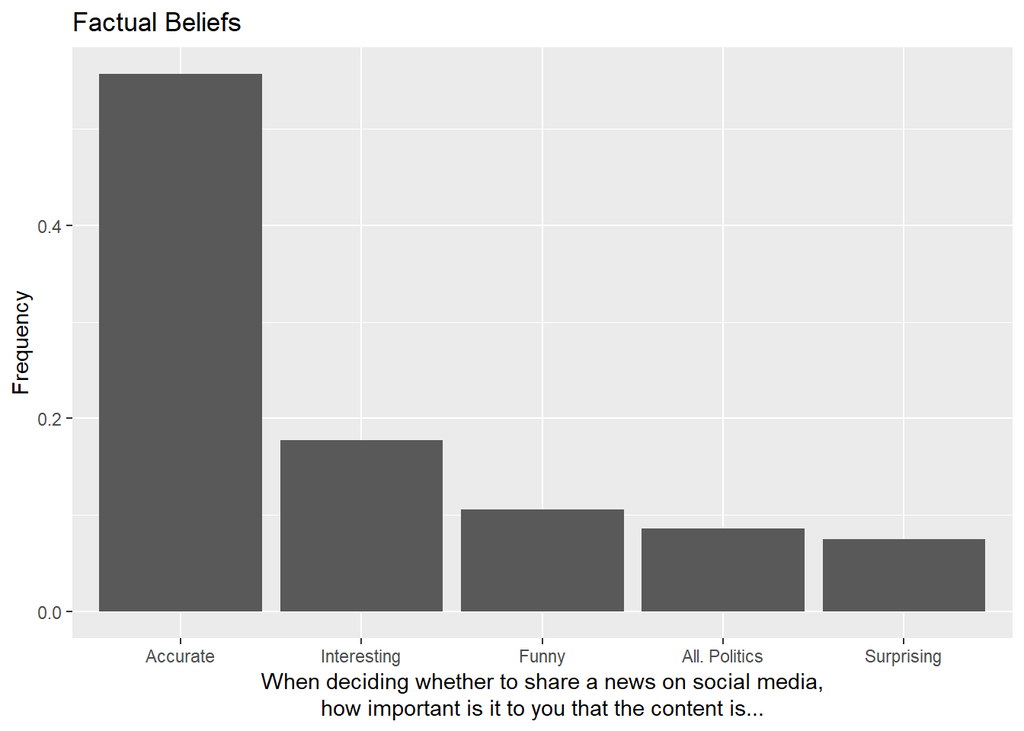

```r
l[[1]] <- part_df %>% filter(!is.na(SOCNORM1_1)) %>% ggplot(aes(x = fct_infreq(SOCNORM1_1))) +
  geom_bar(aes(y = after_stat(count/sum(count)))) +
  labs(title = "Factual Beliefs", x = "When deciding whether to share a news on social media,
       \nhow important is it to you that the content is...",
       y = "Frequency") + th
l[[1]]
```

### All ranking

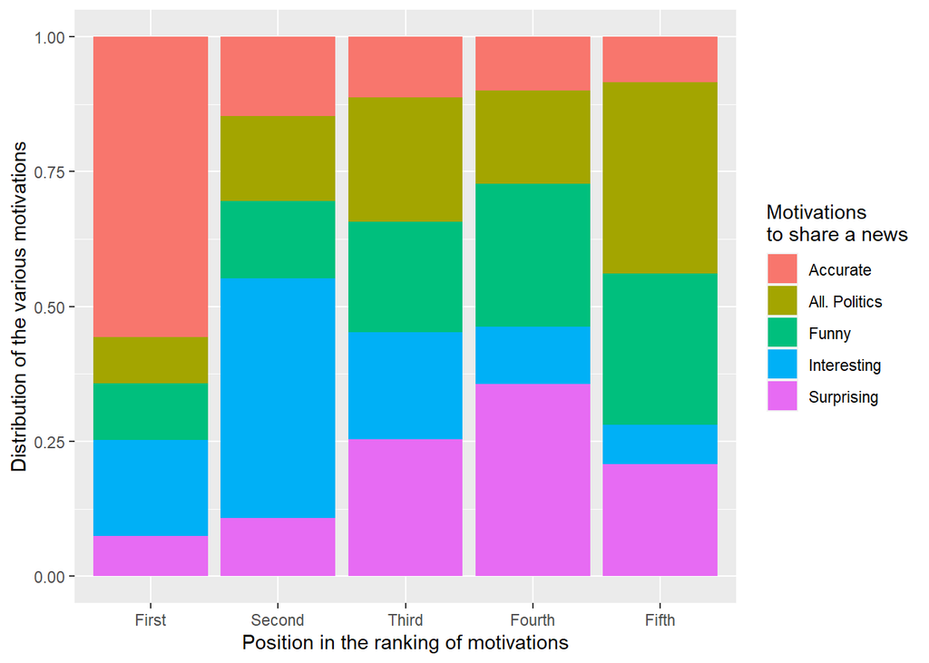

```r
part_df %>% select(id, SOCNORM1_1:SOCNORM1_5) %>%
  pivot_longer(cols = -id,
               names_to = c(".value", "rank"),
               names_sep = "_",
               values_drop_na = T) %>%
  ggplot(aes(x = as.factor(rank), fill = SOCNORM1)) +
  geom_bar(position = "fill") +
  labs(x = "Position in the ranking of motivations",
       y = "Distribution of the various motivations") +
  scale_fill_discrete(name = "Motivations \nto share a news") +
  scale_x_discrete(labels = c("First", "Second", "Third", "Fourth", "Fifth"))
```

## 2 - Empirical Expectations

### In General

```r
table(part_df$SOCNORM2) %>% prop.table()
```

```
##
##                        Almost no one  Few participants (around a quarter)
##                              0.09062                              0.19555
##                         Half of them Most of them (around three quarters)
##                              0.30604                              0.25914
##                   Almost all of them
##                              0.14865
```

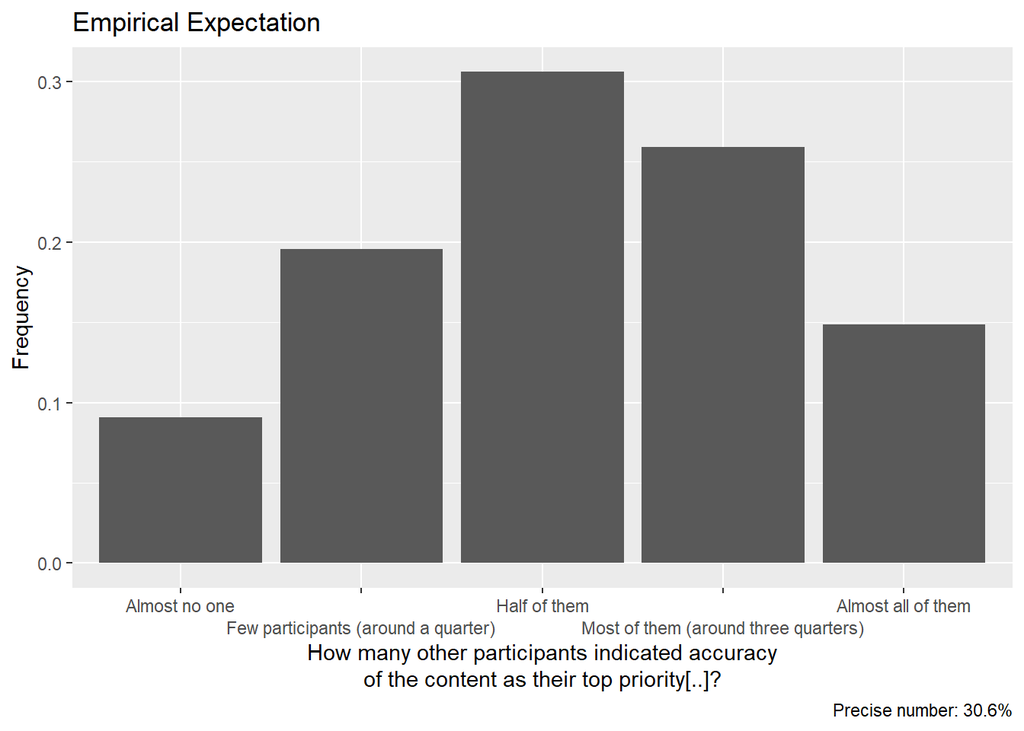

```r
l[[2]] <- part_df %>% filter(!is.na(SOCNORM2)) %>% ggplot(aes(x = SOCNORM2)) +
  geom_bar(aes(y = after_stat(count/sum(count)))) +
  labs(title = "Empirical Expectation",
       x = "How many other participants indicated accuracy
       \nof the content as their top priority[..]?",
       y = "Frequency",
       caption = sprintf("Precise number: %0.1f%%", sort(prop.table(table(part_df$SOCNORM2)))[5]*100))  +
  guides(x = guide_axis(n.dodge = 2)) +
  scale_x_discrete(drop=FALSE) + th
l[[2]]
```

### Depending on First priority

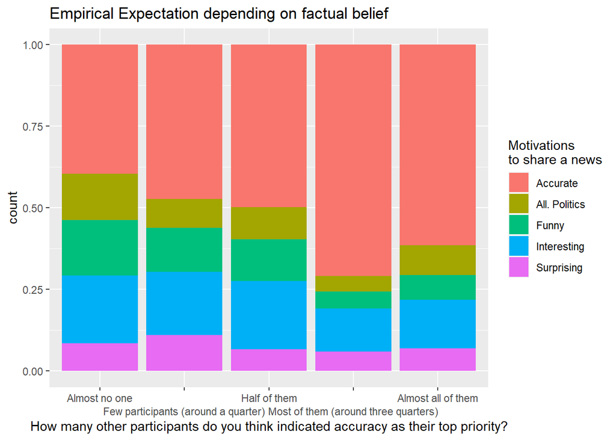

```r
part_df %>% filter(!is.na(SOCNORM2) & !is.na(SOCNORM1_1)) %>%
  ggplot(aes(x = SOCNORM2, fill = SOCNORM1_1)) +
  geom_bar(position = "fill") +
  labs(title = "Empirical Expectation depending on factual belief", x = "How many other participants do you think indicated accuracy as their top priority?") +
  guides(x = guide_axis(n.dodge = 2)) +
  scale_x_discrete(drop=FALSE) +
  scale_fill_discrete(name = "Motivations \nto share a news")
```

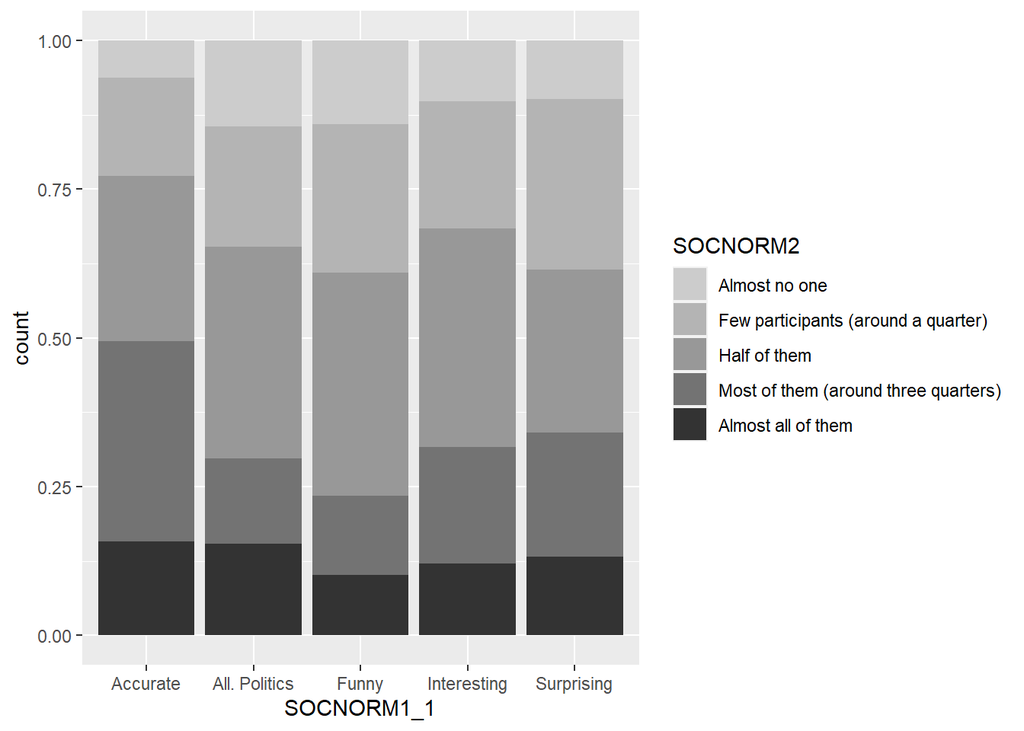

```r
part_df %>% filter(!is.na(SOCNORM2) & !is.na(SOCNORM1_1)) %>%
  ggplot(aes(x = SOCNORM1_1, fill = SOCNORM2)) +
  geom_bar(position = "fill") +
  scale_fill_grey(start=0.8, end=0.2)
```

## 3 - Personal Normative Beliefs

### First Priority

```r
table(part_df$SOCNORM3_1) %>% prop.table() %>% sort(decreasing = T)
```

```
##
##      Accurate   Interesting         Funny All. Politics    Surprising
##      0.601318      0.126853      0.105437      0.093904      0.072488
```

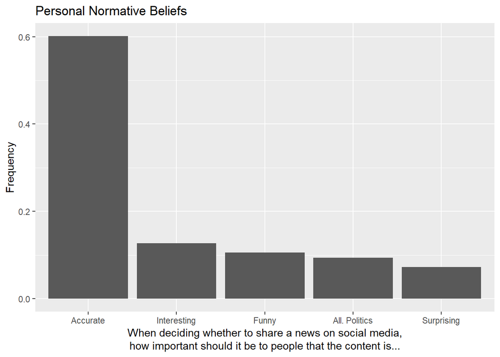

```r
l[[3]] <- part_df %>% filter(!is.na(SOCNORM3_1)) %>% ggplot(aes(x = fct_infreq(SOCNORM3_1))) +
  geom_bar(aes(y = after_stat(count/sum(count)))) +
  labs(title = "Personal Normative Beliefs", x = "When deciding whether to share a news on social media,
       \nhow important should it be to people that the content is...",
       y = "Frequency") + th
l[[3]]
```

### All ranking

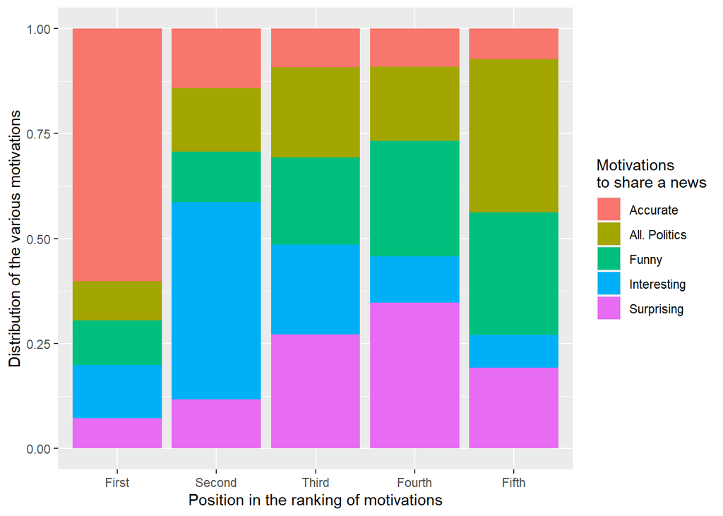

```r
part_df %>% select(id, SOCNORM3_1:SOCNORM3_5) %>%
  pivot_longer(cols = -id,
               names_to = c(".value", "rank"),
               names_sep = "_",
               values_drop_na = T) %>%
  ggplot(aes(x = as.factor(rank), fill = SOCNORM3)) +
  geom_bar(position = "fill") +
  labs(x = "Position in the ranking of motivations",
       y = "Distribution of the various motivations") +
  scale_fill_discrete(name = "Motivations \nto share a news") +
  scale_x_discrete(labels = c("First", "Second", "Third", "Fourth", "Fifth"))
```

## 4 - Normative Expectations

### In General

```r
table(part_df$SOCNORM4) %>% prop.table()
```

```
##
##                        Almost no one  Few participants (around a quarter)
##                             0.076251                             0.175536
##                         Half of them Most of them (around three quarters)
##                             0.305798                             0.281970
##                   Almost all of them
##                             0.160445
```

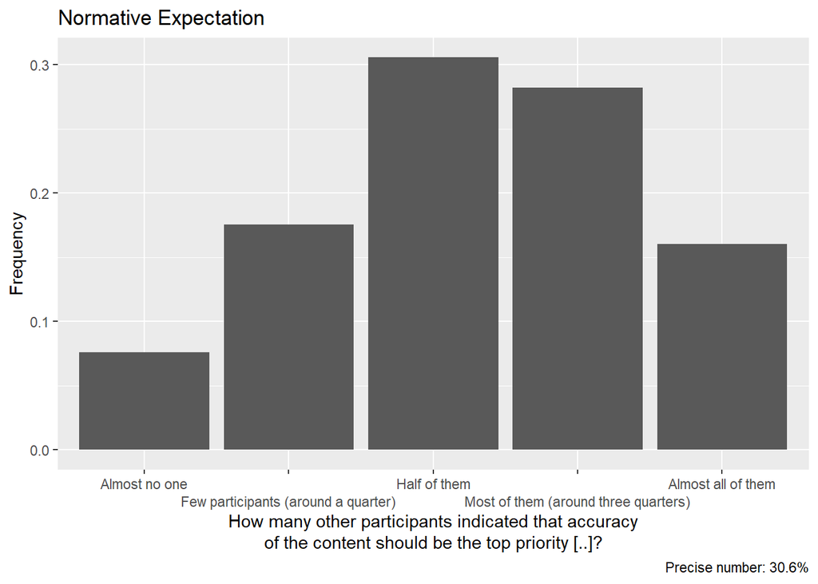

```r
l[[4]] <- part_df %>% filter(!is.na(SOCNORM4)) %>% ggplot(aes(x = SOCNORM4)) +
  geom_bar(aes(y = after_stat(count/sum(count)))) +
  labs(title = "Normative Expectation",
       x = "How many other participants indicated that accuracy
       \nof the content should be the top priority [..]?",
       y = "Frequency",
       caption = sprintf("Precise number: %0.1f%%", sort(prop.table(table(part_df$SOCNORM4)))[5]*100)) +
  guides(x = guide_axis(n.dodge = 2)) +
  scale_x_discrete(drop=FALSE) +
  th
l[[4]]
```